# Praca domowa 2

Maksim Razantsau

## Dane

Dane wykorzystane w Pracy domowej 2 opisują wycenę nieruchmości. Każda obserwacja jest pewną nieruchmością, która posiada informacje takie jak powierzchnia, liczba pokoi, liczba łazienek i wiele więcj. Opis wszystkich kolumn w pliku `README.md`.

## Zadanie 1

Jak wygląda rozkład ceny nieruchomości w poszczególnych kodach pocztowych na przestrzeni lat? Rozważamy kody pocztowe, które mają więcej niż 280 posiadłości.

```r
df$date <- as.Date(gsub("T000000", " ", df$date), format = "%Y%m%d")



zipcodes<- df |>
  group_by(zipcode) |>
  summarise(totalAmount = n()) |>
  filter(totalAmount > 280) |>
  select(zipcode) |>
  pull(zipcode) # pull creates a vector of integeres
                # as.list() creates a list
zipcodes
```

```
##  [1] 98001 98004 98006 98008 98023 98027 98028 98029 98033 98034 98038 98040
## [13] 98042 98052 98053 98056 98058 98059 98065 98074 98075 98092 98103 98106
## [25] 98115 98116 98117 98118 98122 98125 98126 98133 98144 98146 98155 98199
```

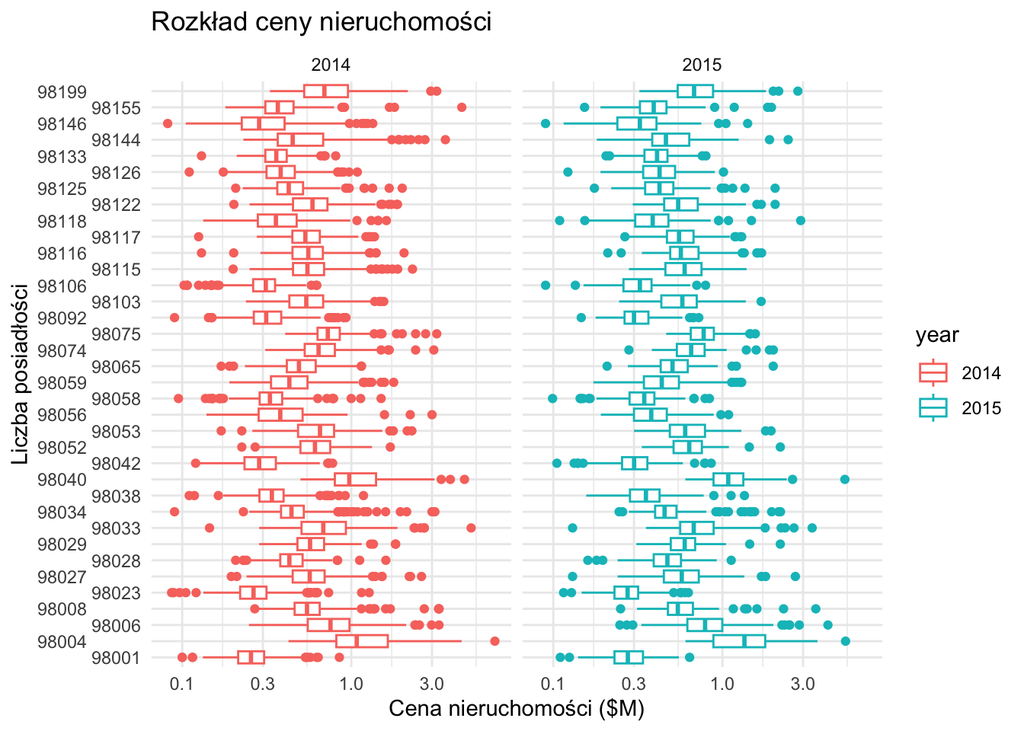

```r
df |>
  filter(zipcode %in% zipcodes, !is.na(price)) |>
  mutate(year = format(date, "%Y"),
         price = price/1000000,
         zipcode = as.factor(zipcode)) |>
  ggplot(aes(y = price, x = zipcode, color = year)) +
  geom_boxplot() +
  scale_y_log10() +
  scale_x_discrete(guide = guide_axis(n.dodge = 2)) +
  facet_wrap(~ year) +
  labs(
    title = "Rozkład ceny nieruchomości",
    y = "Cena nieruchomości ($M)",
    x = "Liczba posiadłości"
  ) +
  theme_minimal() +
  coord_flip()
```

**Rozklad cen dla poczegolnych zipcodes dla roku 2014 oraz 2015 wyglada prawie identycznie, mozliwe oberwacje odstajace**

## Zadanie 2

Czy jest różnica w rozkładzie ceny nierchomości od powierzchni mieszkalnej uwzględniając podział na nieruchomości z piwnicą i bez?

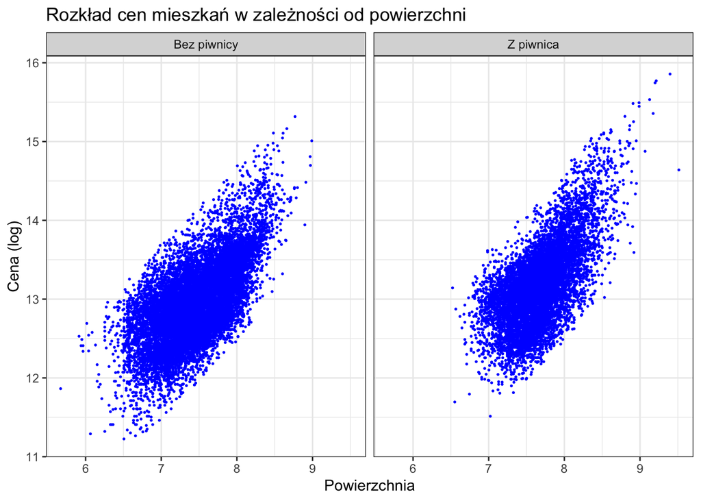

```r
df |>
  mutate(basement = ifelse(sqft_basement != 0,"Z piwnica", "Bez piwnicy")) |>
  ggplot(df, mapping = aes(x = log(sqft_living), y = log(price))) +
  geom_jitter(color='blue', size=0.3, alpha=10) +
  facet_wrap(~ basement) +
  labs(title = "Rozkład cen mieszkań w zależności od powierzchni",
       x = "Powierzchnia",
       y = "Cena (log)") +
  theme_bw()
```

**Rozklad cen dla posiadłości wraz z piwnicą jest bardzie zaburzony outlierami (wiecej przypadkow dzialek o duzej powierzchni skutkuje wieksza cena) Rozklady sa podobne, ale “z piwnica” jest przesuniety ku gorze, co wskazuje na ogolnie wyzsze ceny na posiadlosci z piwnica**

## Zadanie 3

Jaka jest zależność pomiędzy jakością wykończenia nieruchomości a liczbą pięter?

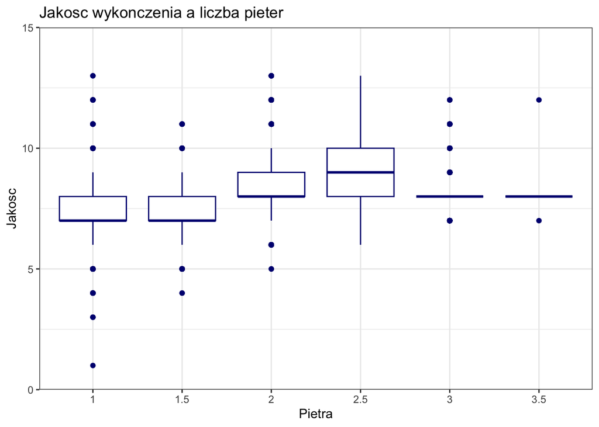

```r
df |>
  ggplot(aes(x = as.factor(floors), y = grade)) +
  geom_boxplot(color = 'navy') +
  scale_y_continuous(expand = c(0,0), limits = c(0,15)) +
  labs(x = "Pietra",
       y = "Jakosc",
       title = "Jakosc wykonczenia a liczba pieter") +
  theme_bw()
```

**Wraz ze wzrostem liczby pieter szansa na dzialke o zlej jakoscie wykonczenia maleje (zazwyczaj liczba piter koreluje dodatnio z cena na posiadłosc) (a iż wieksza cena tym lepsza jakosc wykonczenia):**

## Zadanie 4

Jaka jest zależność między powierzchnią mieszkalną nieruchomości a powierzchnią gruntu w podziale na liczbę sypialni?

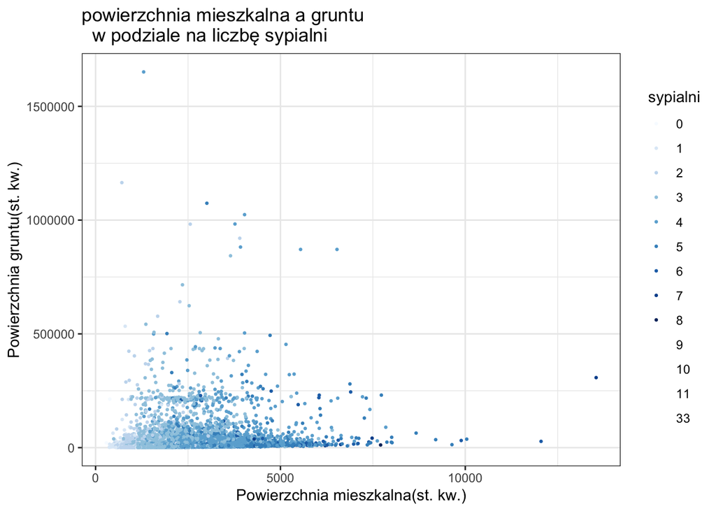

```r
df |>
  mutate(bedrooms = as.factor(bedrooms)) |>
  ggplot(aes(x = sqft_living, y = sqft_lot, color = bedrooms)) +
  geom_point(size=0.5, alpha=10) +
  scale_color_brewer(palette = "Blues") +
  labs(title = "powierzchnia mieszkalna a gruntu
  w podziale na liczbę sypialni",
       x = "Powierzchnia mieszkalna(st. kw.)",
       y = "Powierzchnia gruntu(st. kw.)",
       color = " sypialni") +
  theme_bw()
```

**Wraz ze wzrostem ilosci sypialni rosnie powierzchnia mieszklana Powierzchnia gruntu nie jest w sczegolny sposob zalezna od powierzchni mieszkalnej :**

## Zadanie 5

Rozważmy tylko nieruchomości, które miały remont. W której dekadzie było najwięcej przeprowadzonych remontów? Czy w poszczególnych dekadach jest porównywalny procent nieruchmości dla każdej wartości miary jakości i wykończenia nieruchomości?

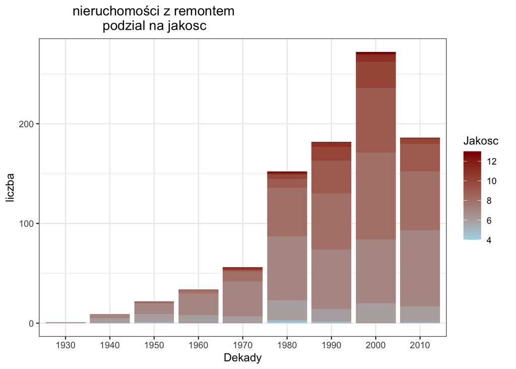

```r
df |>
  filter(yr_renovated > 0) |>
  mutate(decade_renovated = floor(yr_renovated / 10) * 10) |>
  group_by(decade_renovated, grade) |>
  summarise(count = n()) |>
  ggplot(aes(x = as.factor(decade_renovated), y = count, fill = grade)) +
  geom_col() +
  scale_fill_gradient(low='lightblue', high = "darkred", "Jakosc  ") +
  labs(title = "         nieruchomości z remontem
                 podzial na jakosc",
       x = "Dekady",
       y = "liczba") +
  theme_bw()
```

## Zadanie 6

Jak prezentuje się wartość minimalna, średnia i maksymalna ceny nieruchmości w podziele na rok budowy nieruchomości.

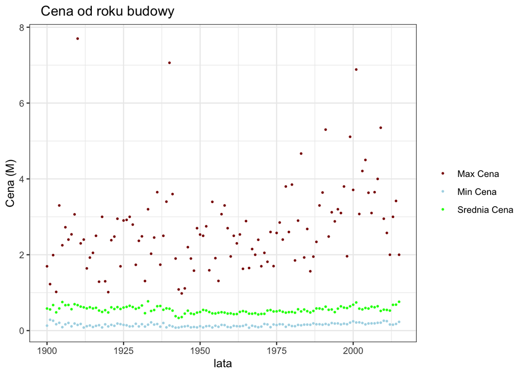

```r
tmp_normal <- df |>
  group_by(yr_built) |>
  summarise(min_price = min(price)/1000000, max_price = max(price)/1000000,
            average_price = mean(price)/1000000)

  tmp_normal |>
  ggplot(aes(x = yr_built)) +
  geom_point(aes(y = min_price, color = "Min Cena"), size = 0.5) +
  geom_point(aes(y = max_price, color = "Max Cena"), size = 0.5) +
  geom_point(aes(y = average_price, color = "Srednia Cena"), size = 0.5) +
  scale_color_manual(values = c("Min Cena" = "lightblue",
                                "Max Cena" = "darkred",
                                "Srednia Cena" = "green"), "") +
    labs(title = "   Cena od roku budowy",
         x = "lata",
         y = "Cena (M)") +
  theme_bw()
```

**brak znaczących zależności ceny od roku budowy nieruchomości moze (cena maksymalna ma lekka tendencje rosnanca) Min oraz Srednia nie wykazuja sie ta zaleznoscia (nawet dla zlogarytmowanej osi OY) :**